2 min read

# Great dataviz examples in rstats

2017/11/20

Here come some stunning examples of data visualizations, all built with R. R code of each diagram is available at the source. Enjoy! #beautiful.

# Plotting geo maps along with subplots in `ggplot2`

I like this one by Ilya Kashnitsky:

[figure not shown]

Similarly, by the same author:

[figure not shown]

Great work, @ikashnitsky!

# Cirlize (Chord) diagrams

Plotting association in a circular form yields aesthetic examples of diagrams, see the following examples

[figure not shown]

This work is from Zuguang Gu; see his package [circlize](https://www.rdocumentation.org/packages/circlize/versions/0.4.1). He is also the author from the corresponding free online [book](http://zuguang.de/circlize_book/book/).

# Grey is your best friend

Providing contect to your data is an important principle in data viz. For example, show the overall data when you focus on a subgroup.

Simon Jackson (@drsimonj) gives a great example:

[figure not shown]

# Beautitful scatter plots

Again, Simon Jackson does it:

[figure not shown]

# Maps with grid

[figure not shown]

See many more examples of nice diagrams at [The R Graph Gallery](https://www.r-graph-gallery.com/)

# Clean chloropleth map

An example of a clean chloropleth map, again from [The R Graph Gallery](https://www.r-graph-gallery.com/)

[figure not shown]

# Pirate attack

Pirate plots, by [Nathaniel Philips](http://nathanieldphillips.com/), are available by the R package yarrr.

[figure not shown]

From the documentation on [this page](https://github.com/ndphillips/yarrr):

> The pirateplot function creates a pirateplot, a transparent (both literally and figuratively) plot for displaying continuous data as a function of 1, 2, or 3 discrete variables. Unlike traditional plots, like barplots and boxplots, the pirateplot shows both raw data (jittered points), descriptive statistics (line and/or bar), and inferential statistics (95% Bayesian Highest Density Intervals or Confidence Intervals), in one plot. While the default plot shows all these elements, the user can easily customize the transparency of each element using additional arguments. See ?pirateplot or https://CRAN.R-project.org/package=yarrr for more details

# Clean R graphs comependium

Teh [Compendium of Clean Graphs in R](http://shinyapps.org/apps/RGraphCompendium/index.php) presents a gallery of, surprise, clean graphs. The graphs are often “simple” in the sense that they do not convey a hell of a lot information, and graph junk is seriously avoied. Many examples are suitable for academia settings.

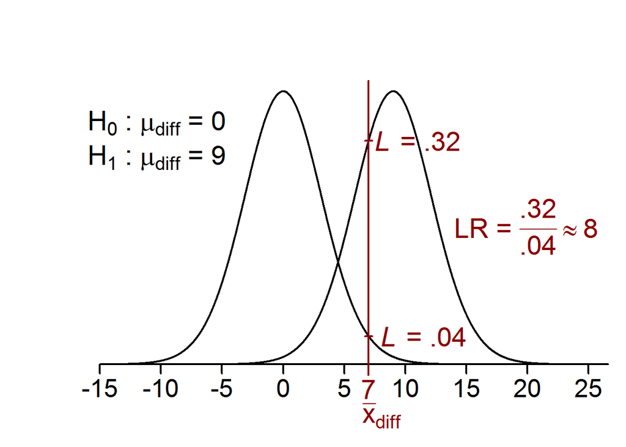

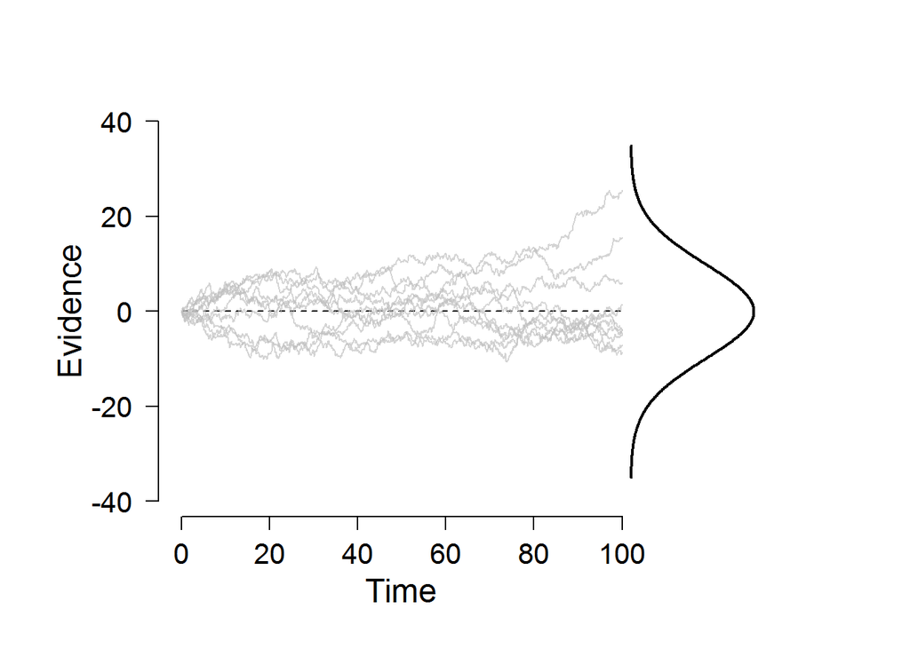

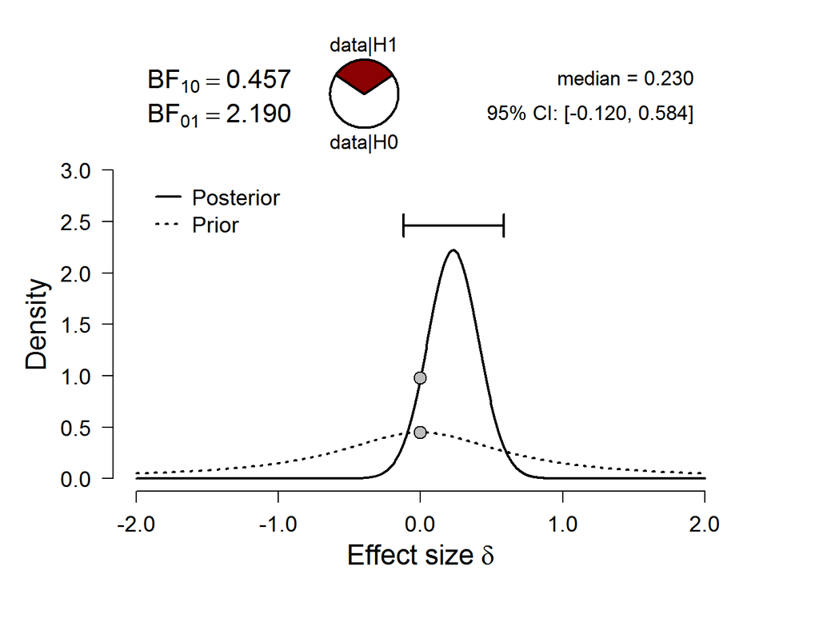

# Questionnaire graph

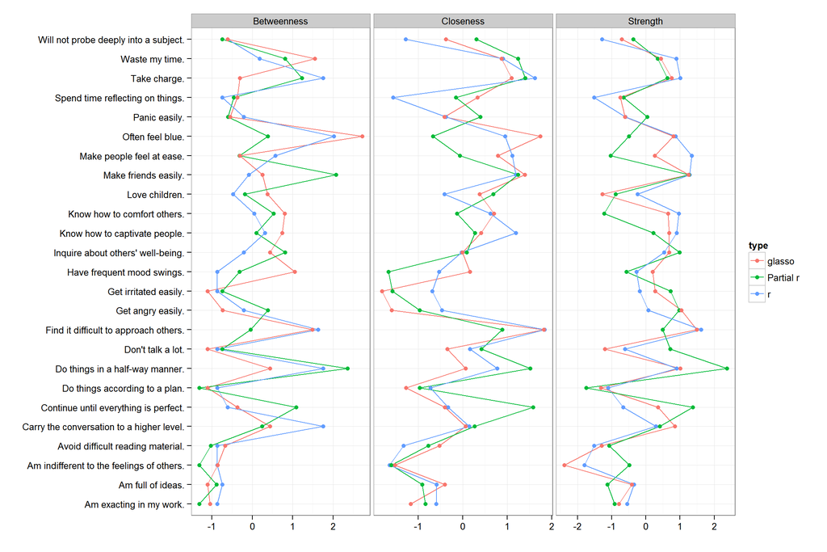

# Survey results with Thomas Rahlf’s book

This example from Thomas Rahlf’s book [Data Design with R](http://www.datendesign-r.de/) is nice:

[figure not shown]

Again suitable for survey results, but somewhat more advanced:

[figure not shown]

# Heatmap

By Thomas Rahlf again; there are many examples of heat or tile maps, but this is one is particularly nice - although made with base R, no ggplot.

[figure not shown]

# Time series

This one by Thomas Rahlf is nice:

[figure not shown]

.

Similarly, and “cleaner”:

[figure not shown]